# 1 Basic edgeR results exploration

Project: edgeR-example.

# 2 Introduction

This report is meant to help explore edgeR (Chen, Chen, Lun, Baldoni, and Smyth, 2025) results and was generated using the `regionReport` (Collado-Torres, Jaffe, and Leek, 2016) package. While the report is rich, it is meant to just start the exploration of the results and exemplify some of the code used to do so. If you need a more in-depth analysis for your specific data set you might want to use the `customCode` argument. This report is based on the vignette of the `DESeq2` (Love, Huber, and Anders, 2014) package which you can find [here](http://www.bioconductor.org/packages/DESeq2).

## 2.1 Code setup

This section contains the code for setting up the rest of the report.

```r
## knitrBoostrap and device chunk options
library('knitr')
opts_chunk$set(bootstrap.show.code = FALSE, dev = device, crop = NULL)
if(!outputIsHTML) opts_chunk$set(bootstrap.show.code = FALSE, dev = device, echo = FALSE)
```

```r
#### Libraries needed

## Bioconductor
library('DESeq2')
if(isEdgeR) library('edgeR')

## CRAN
library('ggplot2')
if(!is.null(theme)) theme_set(theme)
library('knitr')
if(is.null(colors)) {
    library('RColorBrewer')
}
library('pheatmap')
library('DT')
library('sessioninfo')

#### Code setup

## For ggplot
res.df <- as.data.frame(res)

## Sort results by adjusted p-values
ord <- order(res.df$padj, decreasing = FALSE)
res.df <- res.df[ord, ]
features <- rownames(res.df)
res.df <- cbind(data.frame(Feature = features), res.df)
rownames(res.df) <- NULL
```

# 3 PCA

```
## using ntop=500 top features by variance
```

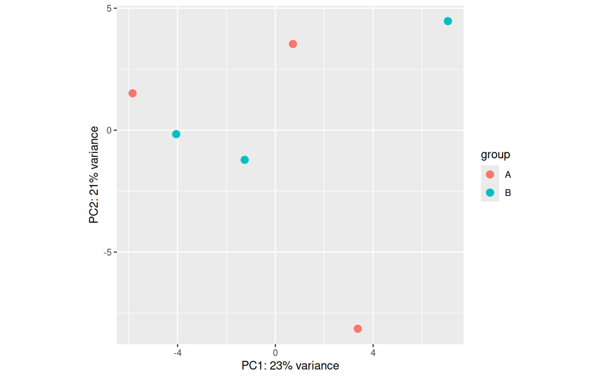

```r
## Transform count data
rld <- tryCatch(rlog(dds), error = function(e) { rlog(dds, fitType = 'mean') })

## Perform PCA analysis and make plot
plotPCA(rld, intgroup = intgroup)
```

```r
## Get percent of variance explained
data_pca <- plotPCA(rld, intgroup = intgroup, returnData = TRUE)
```

```
## using ntop=500 top features by variance
```

```r
percentVar <- round(100 * attr(data_pca, "percentVar"))
```

The above plot shows the first two principal components that explain the variability in the data using the regularized log count data. If you are unfamiliar with principal component analysis, you might want to check the [Wikipedia entry](https://en.wikipedia.org/wiki/Principal_component_analysis) or this [interactive explanation](http://setosa.io/ev/principal-component-analysis/). In this case, the first and second principal component explain 23 and 21 percent of the variance respectively.

# 4 Sample-to-sample distances

```r
## Obtain the sample euclidean distances
sampleDists <- dist(t(assay(rld)))
sampleDistMatrix <- as.matrix(sampleDists)
## Add names based on intgroup
rownames(sampleDistMatrix) <- apply(as.data.frame(colData(rld)[, intgroup]), 1,
    paste, collapse = ' : ')
colnames(sampleDistMatrix) <- NULL

## Define colors to use for the heatmap if none were supplied
if(is.null(colors)) {
    colors <- colorRampPalette( rev(brewer.pal(9, "Blues")) )(255)
}

## Make the heatmap
pheatmap(sampleDistMatrix, clustering_distance_rows = sampleDists,
    clustering_distance_cols = sampleDists, color = colors)
```

[output not shown]

# 5 MA plots

This section contains three MA plots (see [Wikipedia](https://en.wikipedia.org/wiki/MA_plot)) that compare the mean of the normalized counts against the log fold change. They show one point per feature. The points are shown in red if the feature has an adjusted p-value less than `alpha`, that is, the statistically significant features are shown in red.

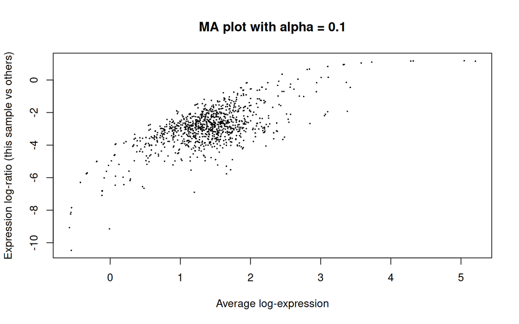

```r
## MA plot with alpha used in DESeq2::results()
plotMA(res, alpha = metadata(res)$alpha, main = paste('MA plot with alpha =',
    metadata(res)$alpha))
```

This first plot shows uses `alpha` = 0.1, which is the `alpha` value used to determine which resulting features were significant when running the function `DESeq2::results()`.

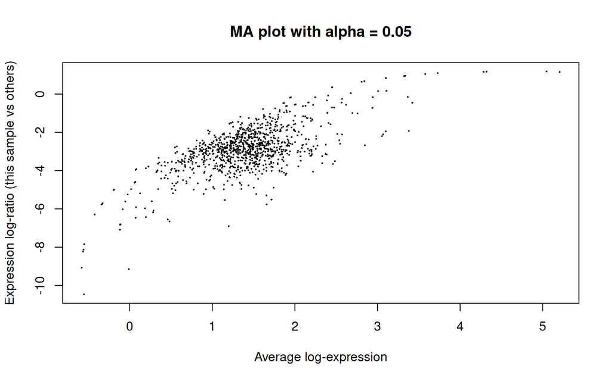

```r
## MA plot with alpha = 1/2 of the alpha used in DESeq2::results()
plotMA(res, alpha = metadata(res)$alpha / 2,
    main = paste('MA plot with alpha =', metadata(res)$alpha / 2))
```

This second MA plot uses `alpha` = 0.05 and can be used agains the first MA plot to identify which features have adjusted p-values between 0.05 and 0.1.

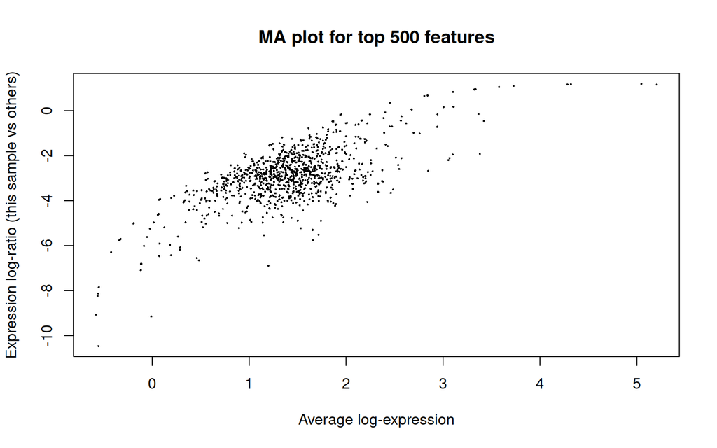

```r
## MA plot with alpha corresponding to the one that gives the nBest features
nBest.actual <- min(nBest, nrow(head(res.df, n = nBest)))
nBest.alpha <- head(res.df, n = nBest)$padj[nBest.actual]
plotMA(res, alpha = nBest.alpha * 1.00000000000001,
    main = paste('MA plot for top', nBest.actual, 'features'))
```

# 6 P-values distribution

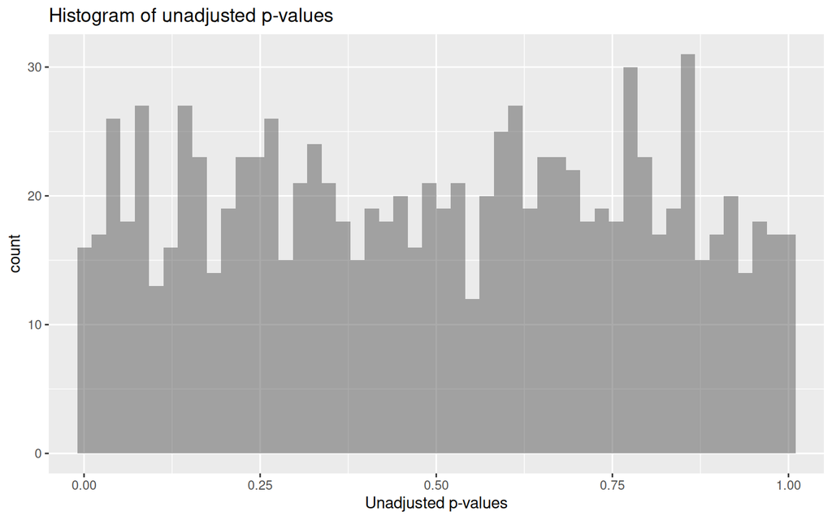

```r
## P-value histogram plot
ggplot(res.df[!is.na(res.df$pvalue), ], aes(x = pvalue)) +
    geom_histogram(alpha=.5, position='identity', bins = 50) +
    labs(title='Histogram of unadjusted p-values') +
    xlab('Unadjusted p-values') +
    xlim(c(0, 1.0005))
```

This plot shows a histogram of the unadjusted p-values. It might be skewed right or left, or flat as shown in the [Wikipedia examples](https://en.wikipedia.org/wiki/Histogram#Examples). The shape depends on the percent of features that are differentially expressed. For further information on how to interpret a histogram of p-values check [David Robinson’s post on this topic](http://varianceexplained.org/statistics/interpreting-pvalue-histogram/).

```r
## P-value distribution summary
summary(res.df$pvalue)
```

```
##      Min.   1st Qu.    Median      Mean   3rd Qu.      Max.
## 0.0007338 0.2456674 0.5039202 0.4979396 0.7529862 1.0000000
```

This is the numerical summary of the distribution of the p-values.

```r
## Split features by different p-value cutoffs
pval_table <- lapply(c(1e-04, 0.001, 0.01, 0.025, 0.05, 0.1, 0.2, 0.3, 0.4, 0.5,
    0.6, 0.7, 0.8, 0.9, 1), function(x) {
    data.frame('Cut' = x, 'Count' = sum(res.df$pvalue <= x, na.rm = TRUE))
})
pval_table <- do.call(rbind, pval_table)
if(outputIsHTML) {
    kable(pval_table, format = 'markdown', align = c('c', 'c'))
} else {
    kable(pval_table)
}
```

| Cut | Count |
| --- | --- |
| 0.0001 | 0 |
| 0.0010 | 2 |
| 0.0100 | 15 |
| 0.0250 | 30 |
| 0.0500 | 59 |
| 0.1000 | 104 |
| 0.2000 | 200 |
| 0.3000 | 309 |
| 0.4000 | 402 |
| 0.5000 | 496 |
| 0.6000 | 592 |
| 0.7000 | 703 |
| 0.8000 | 810 |
| 0.9000 | 906 |
| 1.0000 | 1000 |

This table shows the number of features with p-values less or equal than some commonly used cutoff values.

# 7 Adjusted p-values distribution

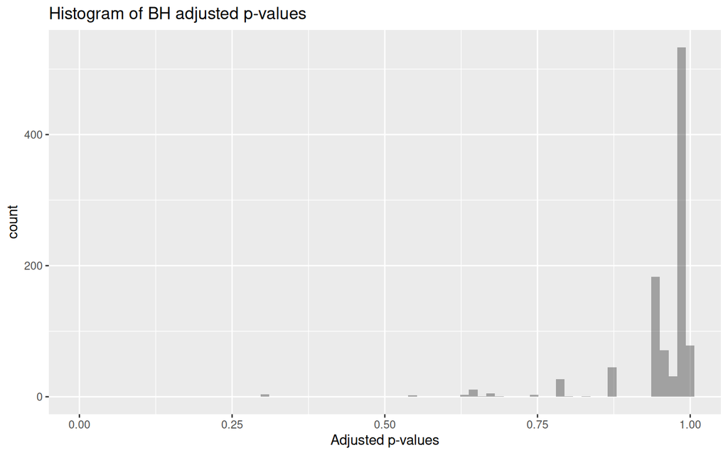

```r
## Adjusted p-values histogram plot
ggplot(res.df[!is.na(res.df$padj), ], aes(x = padj)) +
    geom_histogram(alpha=.5, position='identity', bins = 50) +
    labs(title=paste('Histogram of', elementMetadata(res)$description[grep('adjusted', elementMetadata(res)$description)])) +
    xlab('Adjusted p-values') +
    xlim(c(0, 1.0005))
```

This plot shows a histogram of the BH adjusted p-values. It might be skewed right or left, or flat as shown in the [Wikipedia examples](https://en.wikipedia.org/wiki/Histogram#Examples).

```r
## Adjusted p-values distribution summary
summary(res.df$padj)
```

```
##    Min. 1st Qu.  Median    Mean 3rd Qu.    Max.
##  0.3040  0.9479  0.9821  0.9533  0.9821  1.0000
```

This is the numerical summary of the distribution of the BH adjusted p-values.

```r
## Split features by different adjusted p-value cutoffs
padj_table <- lapply(c(1e-04, 0.001, 0.01, 0.025, 0.05, 0.1, 0.2, 0.3, 0.4, 0.5,
    0.6, 0.7, 0.8, 0.9, 1), function(x) {
    data.frame('Cut' = x, 'Count' = sum(res.df$padj <= x, na.rm = TRUE))
})
padj_table <- do.call(rbind, padj_table)
if(outputIsHTML) {
    kable(padj_table, format = 'markdown', align = c('c', 'c'))
} else {
    kable(padj_table)
}
```

| Cut | Count |
| --- | --- |
| 0.0001 | 0 |
| 0.0010 | 0 |
| 0.0100 | 0 |
| 0.0250 | 0 |
| 0.0500 | 0 |
| 0.1000 | 0 |
| 0.2000 | 0 |
| 0.3000 | 0 |
| 0.4000 | 4 |
| 0.5000 | 4 |
| 0.6000 | 6 |
| 0.7000 | 27 |
| 0.8000 | 57 |
| 0.9000 | 104 |
| 1.0000 | 1000 |

This table shows the number of features with BH adjusted p-values less or equal than some commonly used cutoff values.

# 8 Top features

This interactive table shows the top 500 features ordered by their BH adjusted p-values. Use the search function to find your feature of interest or sort by one of the columns.

```r
## Add search url if appropriate
if(!is.null(searchURL) & outputIsHTML) {
    res.df$Feature <- paste0('<a href="', searchURL, res.df$Feature, '">',
        res.df$Feature, '</a>')
}

for(i in which(colnames(res.df) %in% c('pvalue', 'padj'))) res.df[, i] <- format(res.df[, i], scientific = TRUE)

if(outputIsHTML) {
    datatable(head(res.df, n = nBest), options = list(pagingType='full_numbers', pageLength=10, scrollX='100%'), escape = FALSE, rownames = FALSE) %>% formatRound(which(!colnames(res.df) %in% c('pvalue', 'padj', 'Feature')), digits)
} else {
    res.df_top <- head(res.df, n = 20)
    for(i in which(!colnames(res.df) %in% c('pvalue', 'padj', 'Feature'))) res.df_top[, i] <- round(res.df_top[, i], digits)
    kable(res.df_top)
}
```

| Feature | log2FoldChange | baseMean | LR | pvalue | padj |
| --- | --- | --- | --- | --- | --- |
| gene29 | 5.783131171781656 | 7.019872676424805 | 11.19802016549874 | 8.188465e-04 | 3.040159e-01 |
| gene175 | -4.585829305078827 | 7.49377367880179 | 10.4657776068202 | 1.216063e-03 | 3.040159e-01 |
| gene220 | 5.638596849491405 | 6.929530342051356 | 10.58081118631961 | 1.142675e-03 | 3.040159e-01 |
| gene463 | -5.787456660782046 | 7.00724093955164 | 11.40163019809577 | 7.337969e-04 | 3.040159e-01 |
| gene267 | -5.116810800456541 | 6.608005683052056 | 8.671453948989303 | 3.232332e-03 | 5.387220e-01 |
| gene897 | -2.248975537597578 | 9.10707661463572 | 8.944743563208936 | 2.782692e-03 | 5.387220e-01 |
| gene85 | 2.41821803940391 | 8.716684169055052 | 8.00801488451452 | 4.657076e-03 | 6.269160e-01 |
| gene177 | 4.905119435769245 | 6.517277213625003 | 7.778355921232338 | 5.287590e-03 | 6.269160e-01 |
| gene251 | 4.868007956820119 | 6.503912204461325 | 7.661152943046256 | 5.642244e-03 | 6.269160e-01 |
| gene260 | 1.954615970135037 | 9.086567815209325 | 6.87509468826226 | 8.740513e-03 | 6.437383e-01 |

[output cut: 490 more lines]

# 9 Count plots top features

This section contains plots showing the normalized counts per sample for each group of interest. Only the best 20 features are shown, ranked by their BH adjusted p-values. The Y axis is on the log10 scale and the feature name is shown in the title of each plot.

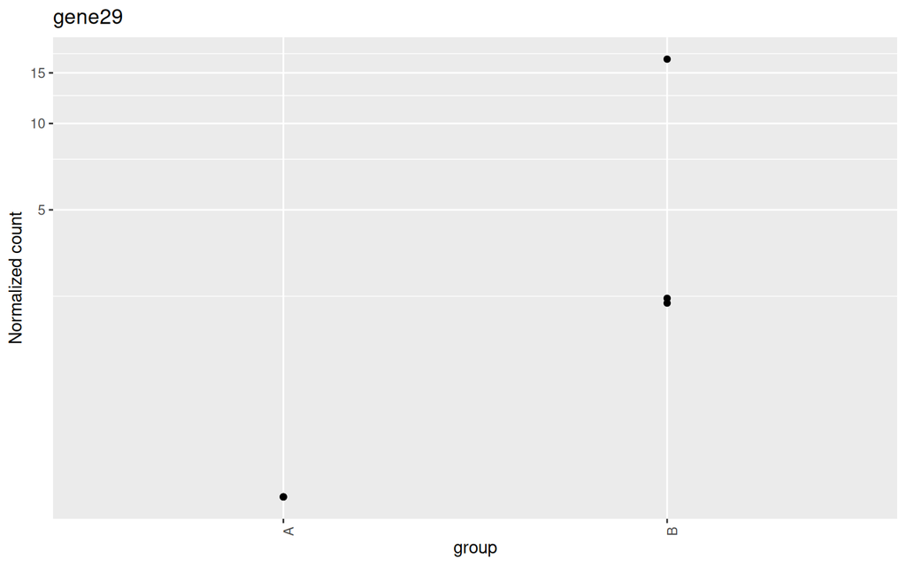

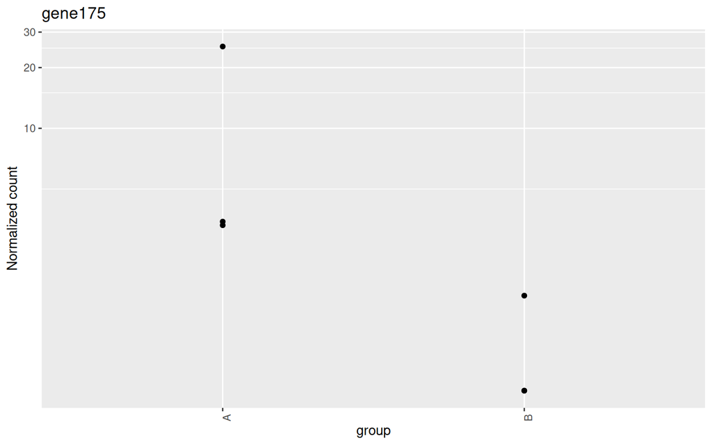

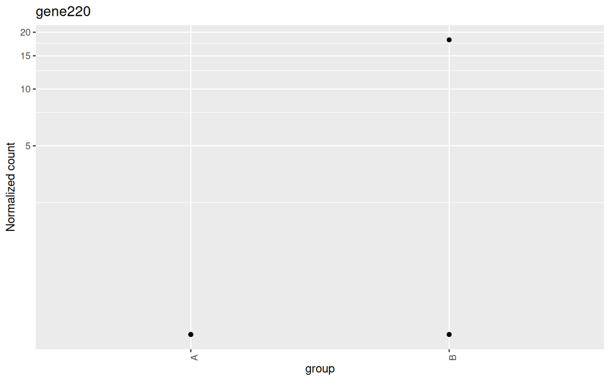

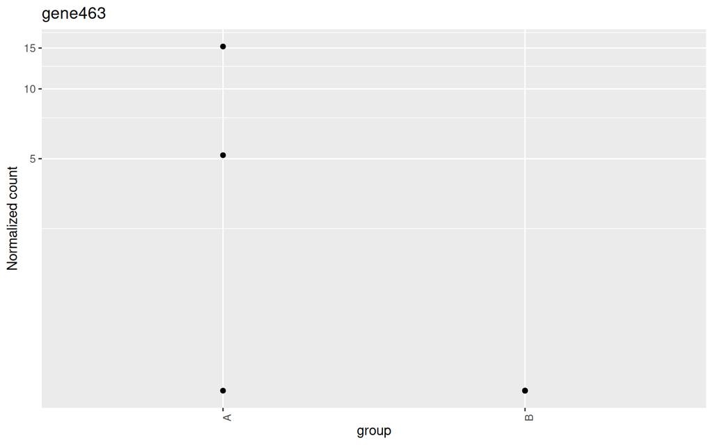

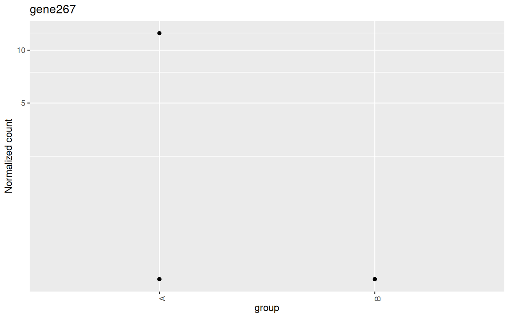

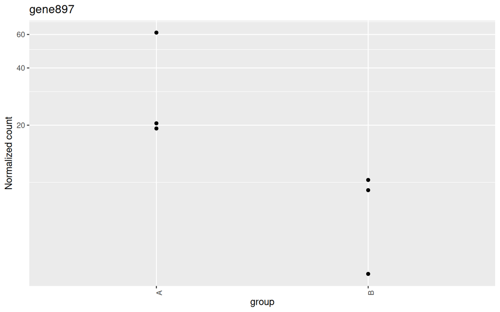

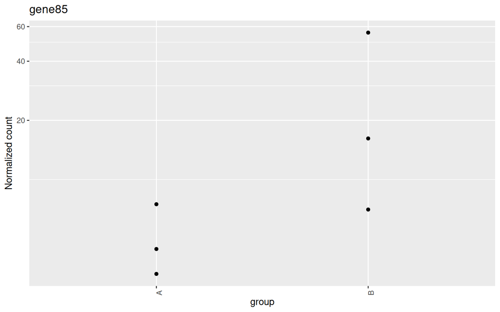

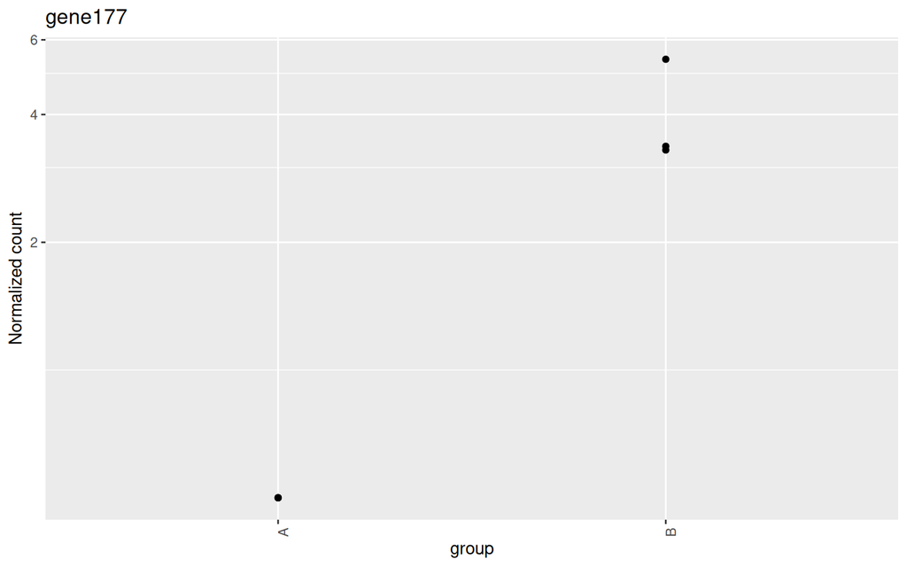

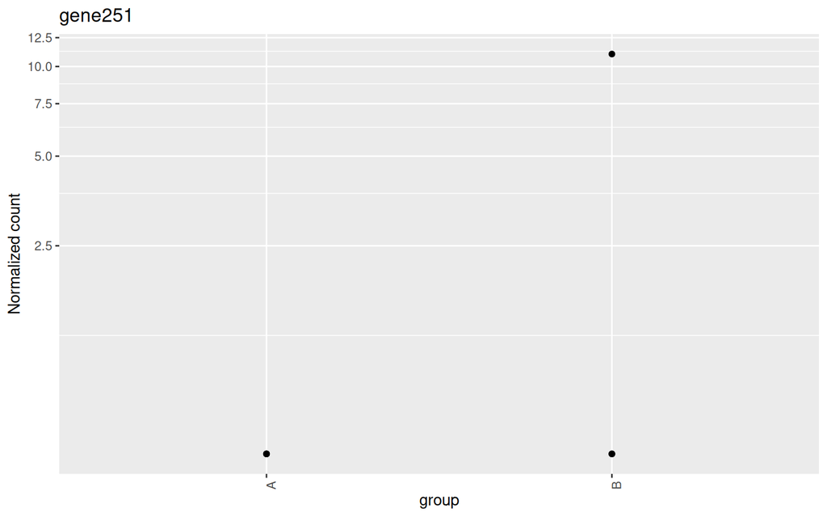

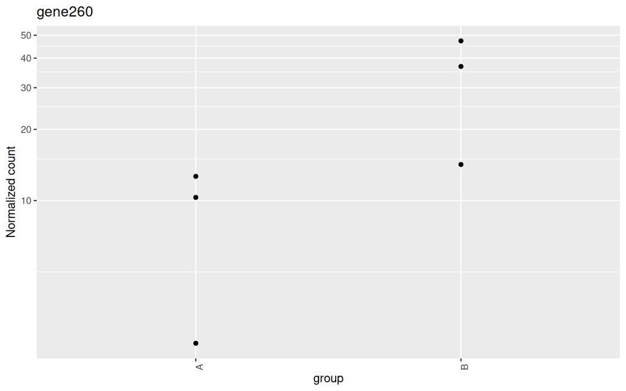

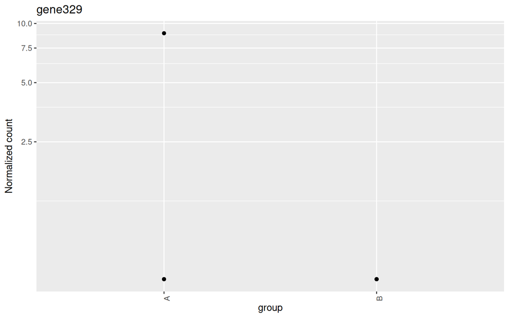

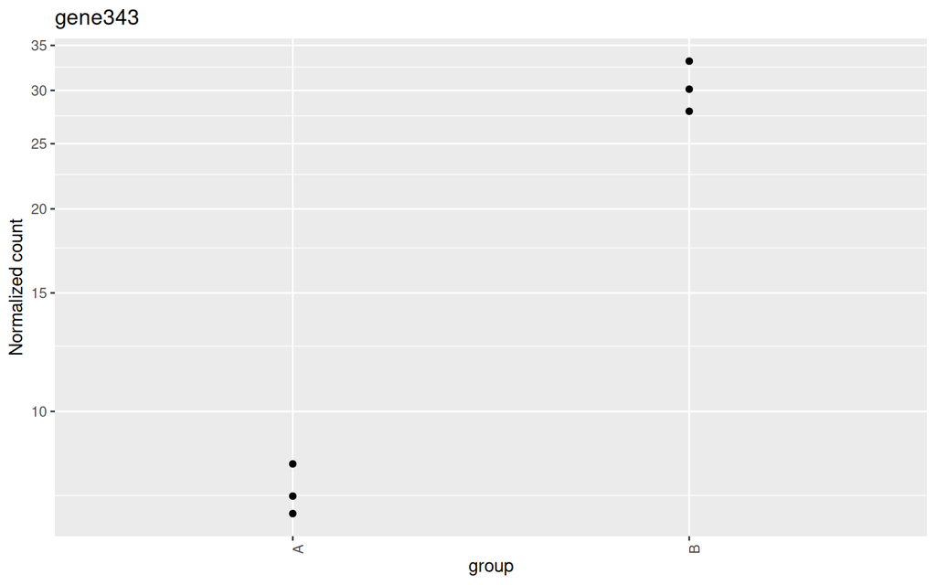

[8 more figures not shown]

```r
plotCounts_gg <- function(i, dds, intgroup) {
    group <- if (length(intgroup) == 1) {
        colData(dds)[[intgroup]]
    } else if (length(intgroup) == 2) {
        lvls <- as.vector(t(outer(levels(colData(dds)[[intgroup[1]]]),
            levels(colData(dds)[[intgroup[2]]]), function(x,
                y) paste(x, y, sep = " : "))))
        droplevels(factor(apply(as.data.frame(colData(dds)[,
            intgroup, drop = FALSE]), 1, paste, collapse = " : "),
            levels = lvls))
    } else {
        factor(apply(as.data.frame(colData(dds)[, intgroup, drop = FALSE]),
            1, paste, collapse = " : "))
    }
    data <- plotCounts(dds, gene=i, intgroup=intgroup, returnData = TRUE)
    ## Change in version 1.15.3
    ## It might not be necessary to have any of this if else, but I'm not
    ## sure that plotCounts(returnData) will always return the 'group' variable.
    if('group' %in% colnames(data)) {
        data$group <- group
    } else {
        data <- cbind(data, data.frame('group' = group))
    }

    ggplot(data, aes(x = group, y = count)) + geom_point() + ylab('Normalized count') + ggtitle(i) + coord_trans(y = "log10") + theme(axis.text.x = element_text(angle = 90, hjust = 1))
}
for(i in head(features, nBestFeatures)) {
    print(plotCounts_gg(i, dds = dds, intgroup = intgroup))
}
```

# 10 edgeR specific plots

## 10.1 Biological coefficient of variation

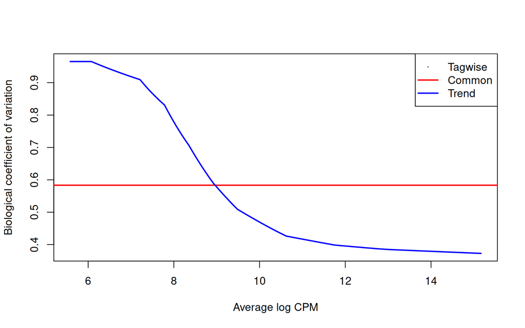

```r
## Make BCV plot for edgeR results
plotBCV(dge)
```

## 10.2 MDS plot of distances

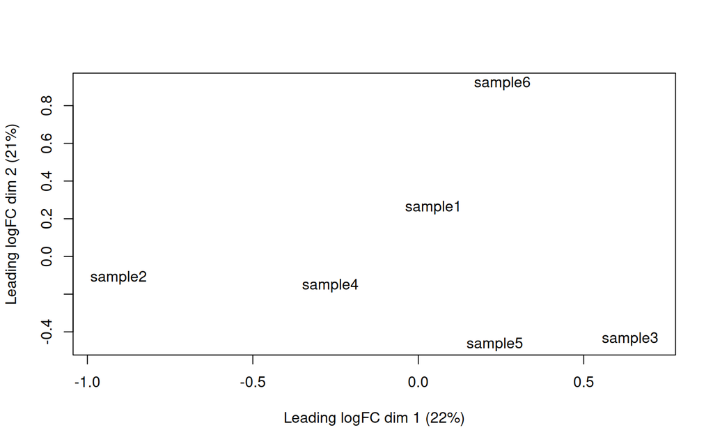

```r
## Make MDS plot for edgeR results
plotMDS(dge)
```

This plot is a multidimensional scaling plot of distances between feature expression profiles. It shows the names of the samples in a two-dimensional scatterplot such that the distances are approximately the log2 fold changes between samples. Check the [edgeR vignette](http://www.bioconductor.org/packages/edgeR) for further details regarding this plot.

# 11 Reproducibility

The input for this report was generated with edgeR (Chen, Chen, Lun et al., 2025) and the resulting features were called significantly differentially expressed if their BH adjusted p-values were less than `alpha` = 0.1. This report was generated in path /__w/regionReport/regionReport/docs/reference using the following call to edgeReport():

```
## edgeReport(dge = dge, object = lrt, project = "edgeR-example",
##     intgroup = "group", outdir = "edgeReport-example")
```

Date the report was generated.

```
## [1] "2026-03-31 17:56:40 UTC"
```

Wallclock time spent generating the report.

```
## Time difference of 9.416 secs
```

Pandoc version used: 3.9.0.2.

# 12 Bibliography

This report was created with `regionReport` (Collado-Torres, Jaffe, and Leek, 2016) using `rmarkdown` (Allaire, Xie, Dervieux et al., 2026) while `knitr` (Xie, 2014) and `DT` (Xie, Cheng, Tan et al., 2025) were running behind the scenes. `pheatmap` (Kolde, 2025) was used to create the sample distances heatmap. Several plots were made with `ggplot2` (Wickham, 2016).

Citations made with *RefManageR* (McLean, 2017). The [BibTeX](http://www.bibtex.org/) file can be found here.

[1] J. Allaire, Y. Xie, C. Dervieux, et al. *rmarkdown: Dynamic Documents for R*. R package version 2.31. 2026. URL: https://github.com/rstudio/rmarkdown.

[2] Y. Chen, L. Chen, A. T. L. Lun, et al. “edgeR v4: powerful differential analysis of sequencing data with expanded functionality and improved support for small counts and larger datasets”. In: *Nucleic Acids Research* 53.2 (2025), p. gkaf018. DOI: 10.1093/nar/gkaf018.

[3] L. Collado-Torres, A. E. Jaffe, and J. T. Leek. “regionReport: Interactive reports for region-level and feature-level genomic analyses [version2; referees: 2 approved, 1 approved with reservations]”. In: *F1000Research* 4 (2016), p. 105. DOI: 10.12688/f1000research.6379.2. URL: http://f1000research.com/articles/4-105/v2.

[4] R. Kolde. *pheatmap: Pretty Heatmaps*. R package version 1.0.13. 2025. DOI: 10.32614/CRAN.package.pheatmap. URL: https://CRAN.R-project.org/package=pheatmap.

[5] M. I. Love, W. Huber, and S. Anders. “Moderated estimation of fold change and dispersion for RNA-seq data with DESeq2”. In: *Genome Biology* 15 (12 2014), p. 550. DOI: 10.1186/s13059-014-0550-8.

[6] M. W. McLean. “RefManageR: Import and Manage BibTeX and BibLaTeX References in R”. In: *The Journal of Open Source Software* (2017). DOI: 10.21105/joss.00338.

[7] H. Wickham. *ggplot2: Elegant Graphics for Data Analysis*. Springer-Verlag New York, 2016. ISBN: 978-3-319-24277-4. URL: https://ggplot2.tidyverse.org.

[8] Y. Xie. “knitr: A Comprehensive Tool for Reproducible Research in R”. In: *Implementing Reproducible Computational Research*. Ed. by V. Stodden, F. Leisch and R. D. Peng. ISBN 978-1466561595. Chapman and Hall/CRC, 2014.

[9] Y. Xie, J. Cheng, X. Tan, et al. *DT: A Wrapper of the JavaScript Library ‘DataTables’*. R package version 0.34.0. 2025. DOI: 10.32614/CRAN.package.DT. URL: https://CRAN.R-project.org/package=DT.